# Data Visualisation

## Decisions about grouping

Consider the following two plots. Both present the same data (from a US survey, so incomes are in dollars) on the incomes of men and women who are either blind or normally sighted:

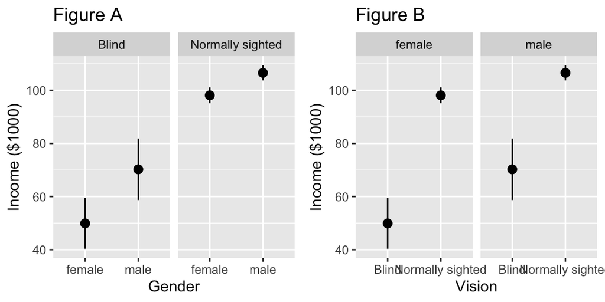

1. Which plot do you prefer, and why?

I don’t have a strong preference between the plots, but I think plot A is probably more useful. My reasoning is that in this plot we can see that:

1. Men are paid more
2. Blind people are paid less
3. The gender-pay gap appears to be larger for blind people

I think that third point is interesting but slightly harder to read/understand from plot B, and so I would choose plot A.

However, we should be cautious about point 3: only 26 people in the dataset are blind (10 women and 16 men), so the means for this group are very uncertain (note the wide error bars). The conclusion is also not robust: if we compare *medians* rather than means, the pay gap is actually *smaller* for blind people (see the discussion of skewed incomes below).

*The idea to take-away is that grouping the data in the plot in different ways can make it easier or more difficult to identify different patterns.*

1. Re-organize the plot below to make it easier to see which level of education has the highest gender pay gap.

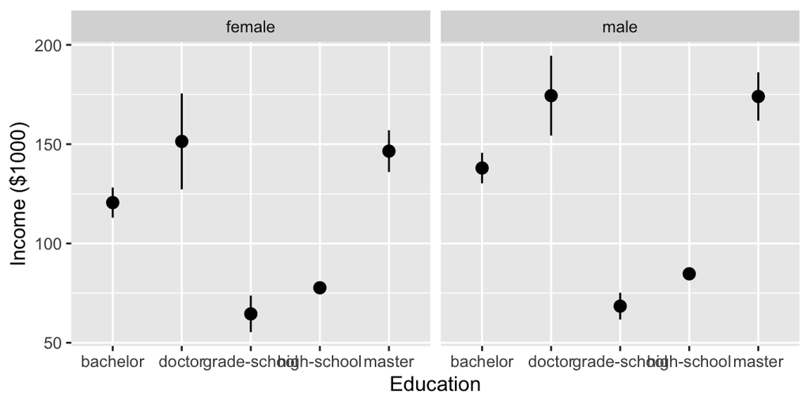

```r
earnings  %>%
  ggplot(aes(x=education, y=income/1000)) +
  facet_grid(~gender) +
  stat_summary() +
  labs(y = "Income ($1000)", x="Education")
```

To reorganise the panels, you will need to amend the variables used to facet the plot.

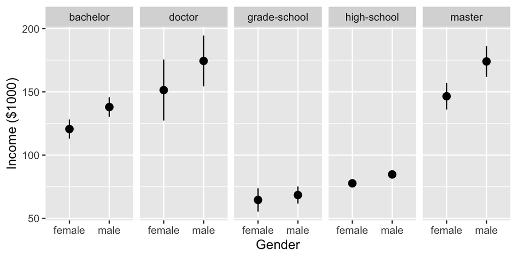

```r
earnings  %>%
  ggplot(aes(x=gender, y=income/1000)) +
  facet_grid(~education) +
  stat_summary() +
  labs(y = "Income ($1000)", x="Gender")
```

2. Try adding `scale_y_log10()` to your updated plot. How does this change the impression you have of the data? Which plot is the most “truthful”?

When we add a log scale, the gender pay gaps appear more similar across the different education categories.

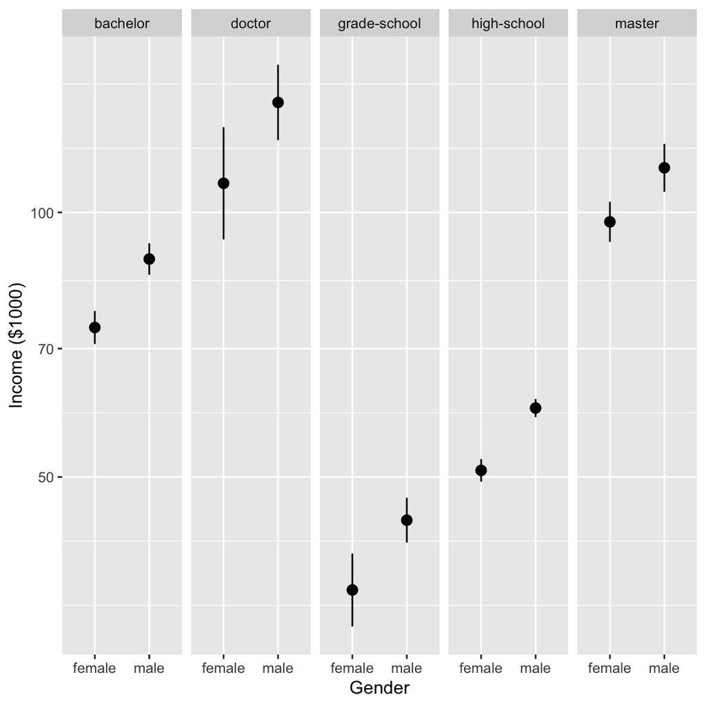

```r
earnings  %>%
  ggplot(aes(x=gender, y=income/1000)) +
  facet_grid(~education) +
  stat_summary() +
  scale_y_log10() +
  labs(y = "Income ($1000)", x="Gender")
```

Either plot can be considered more or less ‘truthful’, depending on your perspective:

- If you believe a $2000 pay gap is the same for people earning around $20,000 as it is for those earning $100,000 then the first plot is more helpful. We can see there that largest pay gaps are among the most educated and so highest-earning.
- If we consider that $2000 means less to those earning very high incomes, then the second plot is more helpful. This plot shows that, relative to total income, the size of the pay gap is pretty consistent across education categories.

However the elephant in the room is that income has a very skewed distribution:

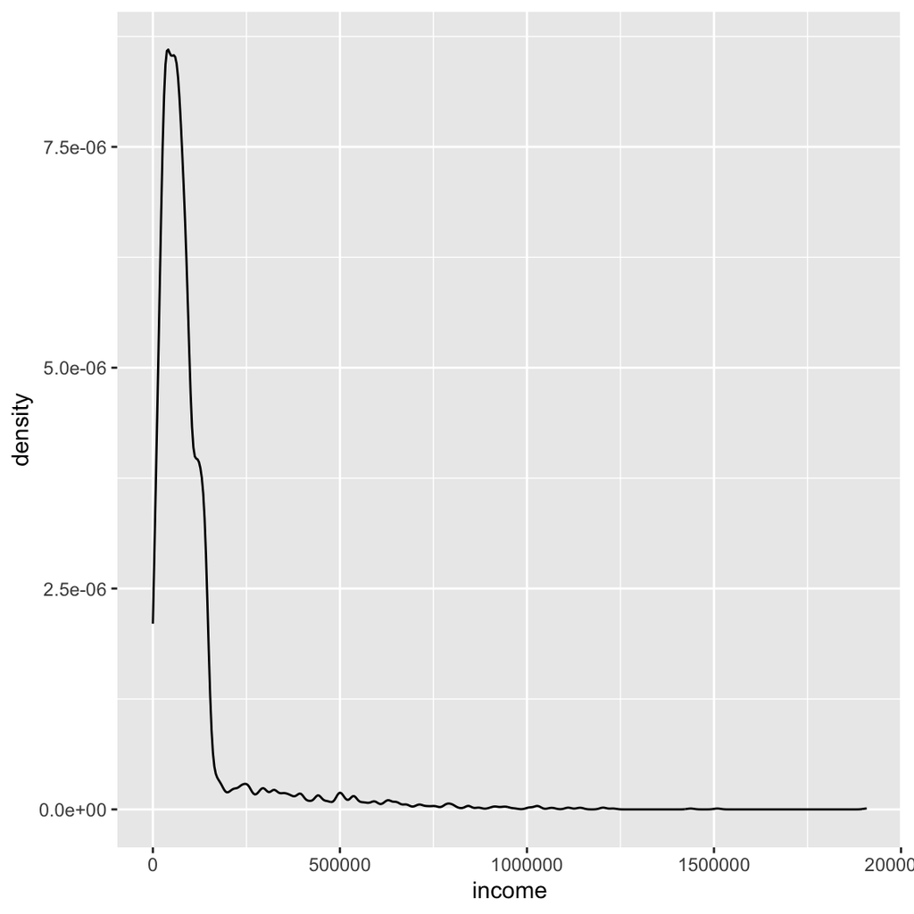

```r
earnings %>%
  ggplot(aes(income)) + geom_density()
```

This means that medians for men/women are very different to the means, and the median gender pay gap is different to the mean gender pay gap:

```r
earnings  %>%
  group_by(blind, gender) %>%
  summarise(m=mean(income)) %>%
  group_by(blind) %>%
  summarise(diff(m)) %>%
  set_names(c("Vision", "Mean pay gap ($)")) %>%
  pander::pander()
```

| Vision | Mean pay gap ($) |
| --- | --- |
| Blind | 20370 |
| Normally sighted | 8473 |

```r
earnings  %>%
  group_by(blind, gender) %>%
  summarise(m=median(income)) %>%
  group_by(blind) %>%
  summarise(diff(m)) %>%
  set_names(c("Vision", "Median pay gap ($)")) %>%
  pander::pander()
```

| Vision | Median pay gap ($) |
| --- | --- |
| Blind | 1735 |
| Normally sighted | 8222 |

The moral here is that different summaries of the data tell different stories: We should explore our data thoroughly, and avoid jumping to conclusions!

# Check your knowledge

1. What does `.Rmd` stand for (what type of file is it)?
2. Give three examples of visual ‘aesthetics’ in which can be adjusted in `ggplot`
3. Which is correct: `labs(x=VARIABLE_NAME)` or `labs(x="Variable name")`. Why is this?
4. What symbol do we use to add a `geom_point()` layer to a plot? Is it `%>%` or `+`?
5. What value do we need to set for a `geom_hline()` layer when adding it to a plot?
6. Explain an advantage of using a log-scale plot for income data? Give an example of another type of data, common in psychology, where a log scale might also be useful.
7. What sort of plots would allow us to check if a distribution is skewed?
8. What effect does `scale_y_log10` have on large vs small values?
9. What is a facet?
10. When might we use facets in our work?
11. What is the difference between `facet_wrap` and `facet_grid`?
12. When choosing variables to use as facets or the x-axis, what principle should guide us?